# ERP-fix: Disaggregate analyses for P2->RT

Hannah

8/21/2019

## 1. Dissaggregate analyses predicting RT from P2 amplitude

The P2.meancent.scale variable was standardized by subject and electrode (i.e., centered around the subject/electrode mean and then scaled to have a standard deviation of 1).

### A. Race categorization task

DV is trial level RT. Incorrect trials and trials with +/- 75 uV artifacts are excluded. Subjects with < 50% trials accepted are excluded (subs 32, 51 and 62).

P2.mean = subject mean (separate subject mean for each electrode)  
P2.meancent.scale = trial level P2 amplitude centered around subject/electrode mean

Total sample n = 65  
Included n = 62

#### B1. Disaggregate within and between subject effects:

Between-subjects effect: **P2.mean**  
Within-subjects effect: **P2.meancent.scale**

```
## lmer(formula = RT ~ P2.mean + P2.meancent.scale + (1 | Subject),
##     data = dat)
```

```
##  Groups   Name        Std.Dev.
##  Subject  (Intercept) 38.215
##  Residual             83.916
```

|  | Estimate | Std. Error | df | t value | Pr(>\|t\|) |
| --- | --- | --- | --- | --- | --- |
| (Intercept) | 457.475 | 4.957 | 65.774 | 92.295 | 0.000 |
| P2.mean | -0.029 | 0.307 | 45434.023 | -0.093 | 0.926 |
| P2.meancent.scale | -3.835 | 0.272 | 94898.031 | -14.083 | 0.000 |

**With effect-coded predictors included:**

```
## lmer(formula = RT ~ P2.mean + P2.meancent.scale * Race.e * Fix.e +
##     (1 | Subject), data = dat)
```

```
##  Groups   Name        Std.Dev.
##  Subject  (Intercept) 38.245
##  Residual             83.816
```

|  | Estimate | Std. Error | df | t value | Pr(>\|t\|) |
| --- | --- | --- | --- | --- | --- |
| (Intercept) | 457.449 | 4.960 | 65.757 | 92.224 | 0.000 |
| P2.mean | -0.035 | 0.307 | 45621.187 | -0.113 | 0.910 |
| P2.meancent.scale | -3.597 | 0.273 | 94892.038 | -13.187 | 0.000 |
| Race.e | 2.760 | 0.273 | 94892.639 | 10.122 | 0.000 |
| Fix.e | 2.975 | 0.273 | 94892.510 | 10.912 | 0.000 |
| P2.meancent.scale:Race.e | -0.676 | 0.273 | 94894.754 | -2.471 | 0.013 |
| P2.meancent.scale:Fix.e | -0.626 | 0.274 | 94895.560 | -2.290 | 0.022 |
| Race.e:Fix.e | -0.153 | 0.273 | 94892.521 | -0.559 | 0.576 |
| P2.meancent.scale:Race.e:Fix.e | 0.458 | 0.274 | 94895.827 | 1.675 | 0.094 |

The within-subject effect for Black trials is -2.93. The within-subject effect for White trials is -4.26.

#### B2. Test within-subject relationship by trial type

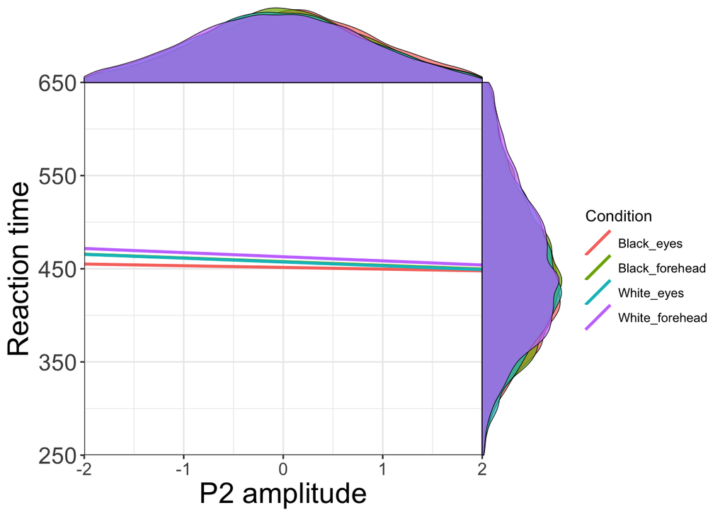

| Target_Race | Fix | Intercept | Slope | Lower_95%CI | Upper_95%CI |
| --- | --- | --- | --- | --- | --- |
| Black | eyes | 451 | -1.84 | -2.92 | -0.75 |
| Black | forehead | 458 | -4.01 | -5.13 | -2.88 |
| White | eyes | 457 | -4.10 | -5.17 | -3.03 |
| White | forehead | 463 | -4.44 | -5.53 | -3.35 |

**Zoomed in:**

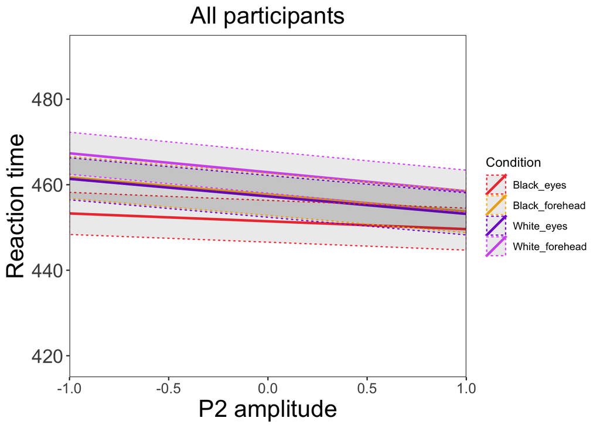

## 2. Examining between/within stimulus group effects

To examine the P2->RT relationship within stimulus type and between stimulus type, I created two new variables. P2.withinSub.betweenStim = mean P2 for each stimulus type, centered within sub P2.withinSub.withinStim = trial level P2, centered within each stim type, centered within sub P2.withinSub.withinStim.scale = trial level P2, centered within each stim type, centered within sub, standardized

```
## Linear mixed model fit by REML. t-tests use Satterthwaite's method [
## lmerModLmerTest]
## Formula:
## RT ~ P2.mean + P2.withinSub.withinStim + P2.withinSub.betweenStim +
##     (1 | Subject)
##    Data: dat
##
## REML criterion at convergence: 1111096
##
## Scaled residuals:
##     Min      1Q  Median      3Q     Max
## -3.3201 -0.6649 -0.1112  0.5363  4.5659
##
## Random effects:
##  Groups   Name        Variance Std.Dev.
##  Subject  (Intercept) 1460     38.22
##  Residual             7036     83.88
## Number of obs: 94962, groups:  Subject, 62
##
## Fixed effects:
##                            Estimate Std. Error         df t value Pr(>|t|)
## (Intercept)               4.575e+02  4.957e+00  6.577e+01  92.296   <2e-16
## P2.mean                  -2.862e-02  3.071e-01  4.547e+04  -0.093    0.926
## P2.withinSub.withinStim  -3.950e-01  3.141e-02  9.490e+04 -12.575   <2e-16
## P2.withinSub.betweenStim -2.227e+00  2.041e-01  9.490e+04 -10.916   <2e-16
##
## (Intercept)              ***
## P2.mean
## P2.withinSub.withinStim  ***
## P2.withinSub.betweenStim ***
## ---
## Signif. codes:  0 '***' 0.001 '**' 0.01 '*' 0.05 '.' 0.1 ' ' 1
##
## Correlation of Fixed Effects:
##              (Intr) P2.men P2.wthnSb.wS
## P2.mean      -0.195
## P2.wthnSb.wS  0.000  0.000
## P2.wthnSb.bS  0.000  0.000  0.000
```

```
## Linear mixed model fit by REML. t-tests use Satterthwaite's method [
## lmerModLmerTest]
## Formula:
## RT ~ P2.mean + P2.withinSub.withinStim.scale + P2.withinSub.betweenStim +
##     (1 | Subject)
##    Data: dat
##
## REML criterion at convergence: 1111091
##
## Scaled residuals:
##     Min      1Q  Median      3Q     Max
## -3.3201 -0.6649 -0.1112  0.5363  4.5659
##
## Random effects:
##  Groups   Name        Variance Std.Dev.
##  Subject  (Intercept) 1460     38.22
##  Residual             7036     83.88
## Number of obs: 94962, groups:  Subject, 62
##
## Fixed effects:
##                                 Estimate Std. Error         df t value
## (Intercept)                    4.575e+02  4.957e+00  6.577e+01  92.296
## P2.mean                       -2.862e-02  3.071e-01  4.547e+04  -0.093
## P2.withinSub.withinStim.scale -3.423e+00  2.722e-01  9.490e+04 -12.575
## P2.withinSub.betweenStim      -2.227e+00  2.041e-01  9.490e+04 -10.916
##                               Pr(>|t|)
## (Intercept)                     <2e-16 ***
## P2.mean                          0.926
## P2.withinSub.withinStim.scale   <2e-16 ***
## P2.withinSub.betweenStim        <2e-16 ***
## ---
## Signif. codes:  0 '***' 0.001 '**' 0.01 '*' 0.05 '.' 0.1 ' ' 1
##
## Correlation of Fixed Effects:
##             (Intr) P2.men P2.S.S.
## P2.mean     -0.195
## P2.wthnS.S.  0.000  0.000
## P2.wthnSb.S  0.000  0.000  0.000
```